# 16_conical_ratio

## 16_conical_ratio

#### Question

1. A circle with radius $R=4$ ft is cut to a sector with an angle of $\theta=\frac{7\pi}{6}$ radians.

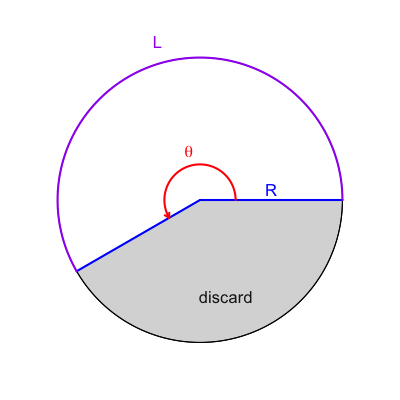

   By connecting the initial side and terminal side, the sector is bent (in 3 dimensions) into a [right-circular cone](https://en.wikipedia.org/wiki/Cone) with height $h$ and radius $r$. Notice the cone’s [slant height](https://en.wikipedia.org/wiki/Cone#Slant_height) equals the radius of the original circle ($R$) and the circumference of the cone matches the arc length ($L$) of the original circle.

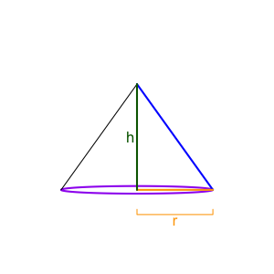

   Find the ratio of the cone’s height to the cone’s radius.

   $$\frac{h}{r} ~=~ ?$$

   The tolerance is $\pm 0.01$.

#### Question

2. A circle with radius $R=4$ ft is cut to a sector with an angle of $\theta=\frac{5\pi}{4}$ radians.

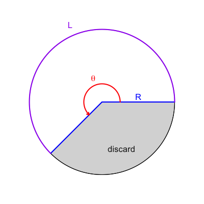

   By connecting the initial side and terminal side, the sector is bent (in 3 dimensions) into a [right-circular cone](https://en.wikipedia.org/wiki/Cone) with height $h$ and radius $r$. Notice the cone’s [slant height](https://en.wikipedia.org/wiki/Cone#Slant_height) equals the radius of the original circle ($R$) and the circumference of the cone matches the arc length ($L$) of the original circle.

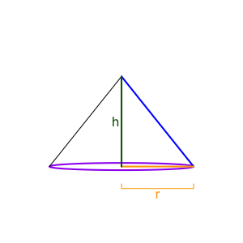

   Find the ratio of the cone’s height to the cone’s radius.

   $$\frac{h}{r} ~=~ ?$$

   The tolerance is $\pm 0.01$.

#### Question

3. A circle with radius $R=6$ ft is cut to a sector with an angle of $\theta=\frac{3\pi}{5}$ radians.

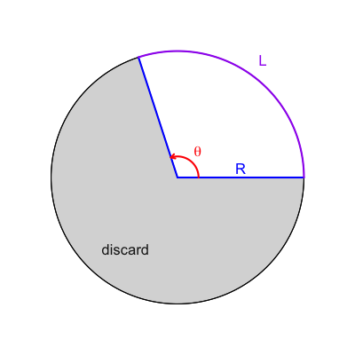

   By connecting the initial side and terminal side, the sector is bent (in 3 dimensions) into a [right-circular cone](https://en.wikipedia.org/wiki/Cone) with height $h$ and radius $r$. Notice the cone’s [slant height](https://en.wikipedia.org/wiki/Cone#Slant_height) equals the radius of the original circle ($R$) and the circumference of the cone matches the arc length ($L$) of the original circle.

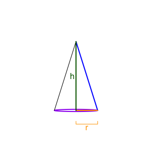

   Find the ratio of the cone’s height to the cone’s radius.

   $$\frac{h}{r} ~=~ ?$$

   The tolerance is $\pm 0.01$.

#### Question

4. A circle with radius $R=4$ ft is cut to a sector with an angle of $\theta=\frac{5\pi}{7}$ radians.

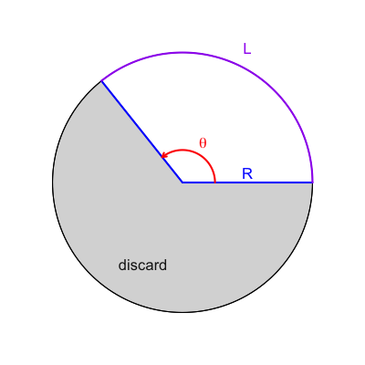

   By connecting the initial side and terminal side, the sector is bent (in 3 dimensions) into a [right-circular cone](https://en.wikipedia.org/wiki/Cone) with height $h$ and radius $r$. Notice the cone’s [slant height](https://en.wikipedia.org/wiki/Cone#Slant_height) equals the radius of the original circle ($R$) and the circumference of the cone matches the arc length ($L$) of the original circle.

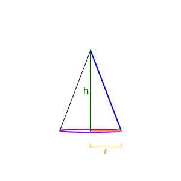

   Find the ratio of the cone’s height to the cone’s radius.

   $$\frac{h}{r} ~=~ ?$$

   The tolerance is $\pm 0.01$.

#### Question

5. A circle with radius $R=5$ ft is cut to a sector with an angle of $\theta=\frac{7\pi}{4}$ radians.

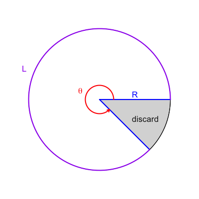

   By connecting the initial side and terminal side, the sector is bent (in 3 dimensions) into a [right-circular cone](https://en.wikipedia.org/wiki/Cone) with height $h$ and radius $r$. Notice the cone’s [slant height](https://en.wikipedia.org/wiki/Cone#Slant_height) equals the radius of the original circle ($R$) and the circumference of the cone matches the arc length ($L$) of the original circle.

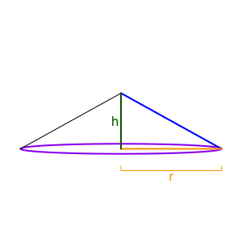

   Find the ratio of the cone’s height to the cone’s radius.

   $$\frac{h}{r} ~=~ ?$$

   The tolerance is $\pm 0.01$.

#### Question

6. A circle with radius $R=5$ ft is cut to a sector with an angle of $\theta=\frac{5\pi}{9}$ radians.

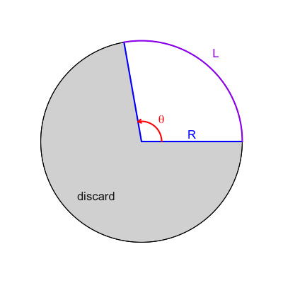

   By connecting the initial side and terminal side, the sector is bent (in 3 dimensions) into a [right-circular cone](https://en.wikipedia.org/wiki/Cone) with height $h$ and radius $r$. Notice the cone’s [slant height](https://en.wikipedia.org/wiki/Cone#Slant_height) equals the radius of the original circle ($R$) and the circumference of the cone matches the arc length ($L$) of the original circle.

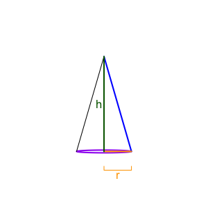

   Find the ratio of the cone’s height to the cone’s radius.

   $$\frac{h}{r} ~=~ ?$$

   The tolerance is $\pm 0.01$.

#### Question

7. A circle with radius $R=4$ ft is cut to a sector with an angle of $\theta=\frac{5\pi}{3}$ radians.

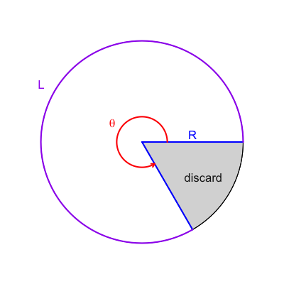

   By connecting the initial side and terminal side, the sector is bent (in 3 dimensions) into a [right-circular cone](https://en.wikipedia.org/wiki/Cone) with height $h$ and radius $r$. Notice the cone’s [slant height](https://en.wikipedia.org/wiki/Cone#Slant_height) equals the radius of the original circle ($R$) and the circumference of the cone matches the arc length ($L$) of the original circle.

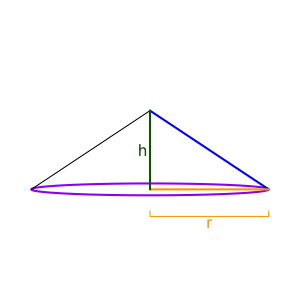

   Find the ratio of the cone’s height to the cone’s radius.

   $$\frac{h}{r} ~=~ ?$$

   The tolerance is $\pm 0.01$.

#### Question

8. A circle with radius $R=8$ ft is cut to a sector with an angle of $\theta=\frac{9\pi}{8}$ radians.

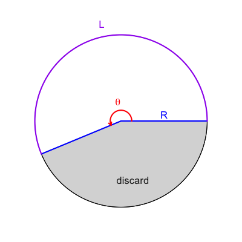

   By connecting the initial side and terminal side, the sector is bent (in 3 dimensions) into a [right-circular cone](https://en.wikipedia.org/wiki/Cone) with height $h$ and radius $r$. Notice the cone’s [slant height](https://en.wikipedia.org/wiki/Cone#Slant_height) equals the radius of the original circle ($R$) and the circumference of the cone matches the arc length ($L$) of the original circle.

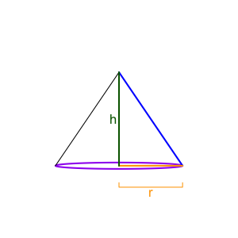

   Find the ratio of the cone’s height to the cone’s radius.

   $$\frac{h}{r} ~=~ ?$$

   The tolerance is $\pm 0.01$.